# In-Class Exercise

Eren Melih Altun

11/4/2020

## Introduction

The aim of this document is to analyze Istanbul Property Dataset by using `dplyr` and `ggplot2` mainly. You may find the libraries that used during the analysis in the below code chunk. You can use the button in the right upper corner of this document to show all code chunks or simply just press the code button of every code chunk that you want to see.

```r
library(dplyr)
library(tidyverse)
library(ggplot2)
library(readxl)
library(lubridate)
library(reshape2)
```

## Data Cleaning

There were some explanations at the end of our Excel file so `n_max` parameter was used to limit the number of rows to be read. `Tarih` column converted to `Date` format by using `paste0` and `as.Date` functions. All column names changed to make them explanatory. Also we can see that there are some missing values which `ggplot` will help us to ignore them.

```r
data<-read_xlsx(file.choose(),n_max = 130)
data$Tarih<-paste0(data$Tarih,as.character("-01"))
data$Tarih<-as.Date(data$Tarih, format="%Y-%m-%d")

data<-rename(data,Tarih=Tarih,
             Toplam_Konut=`TP AKONUTSAT1 T40`,
             Ipotek= `TP AKONUTSAT2 T40`,
             Ilk_El=`TP AKONUTSAT3 T40`,
             Ikinci_El=`TP AKONUTSAT4 T40`,
             Yabanci=`TP DISKONSAT ISTANBUL`,
             Yeni_Endeks=`TP HEDONIKYKFE IST`,
             TR10=`TP HKFE02`,
             Birim_Fiyat=`TP TCBF02 ISTANBUL`)

head(data)
```

```
## # A tibble: 6 x 9
##   Tarih      Toplam_Konut Ipotek Ilk_El Ikinci_El Yabanci Yeni_Endeks  TR10
##   <date>            <dbl>  <dbl>  <dbl>     <dbl>   <dbl>       <dbl> <dbl>
## 1 2010-01-01           NA     NA     NA        NA      NA        35.9  36
## 2 2010-02-01           NA     NA     NA        NA      NA        36.6  36.2
## 3 2010-03-01           NA     NA     NA        NA      NA        37.4  36.5
## 4 2010-04-01           NA     NA     NA        NA      NA        38    36.9
## 5 2010-05-01           NA     NA     NA        NA      NA        38    37.1
## 6 2010-06-01           NA     NA     NA        NA      NA        37.6  37
## # ... with 1 more variable: Birim_Fiyat <dbl>
```

```r
sapply(data, function(x) sum(is.na(x)))
```

```
##        Tarih Toplam_Konut       Ipotek       Ilk_El    Ikinci_El      Yabanci
##            0           36           36           36           36           36
##  Yeni_Endeks         TR10  Birim_Fiyat
##            1            1            1
```

## Distribution of Variables

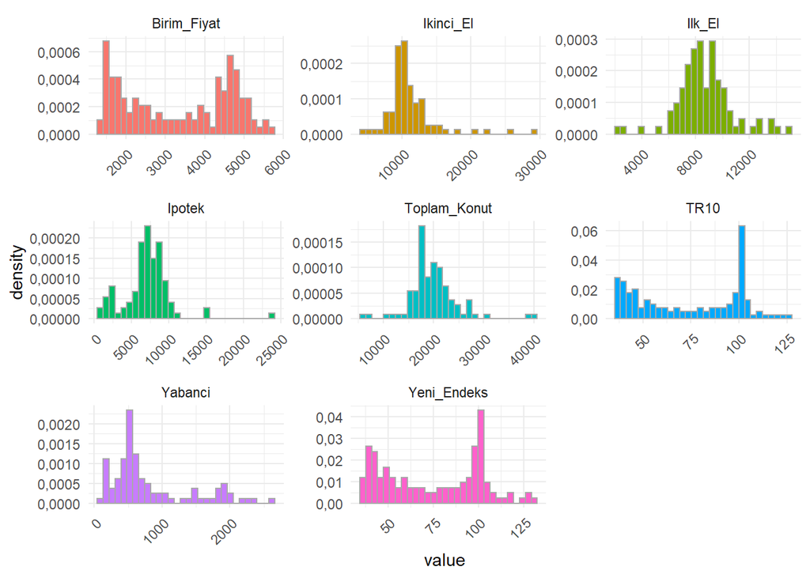

```r
data %>%
  select(Toplam_Konut:Birim_Fiyat) %>%
  gather() %>%
  ggplot(aes(x=value)) +
  geom_histogram(mapping = aes(y=..density..,fill=key), color="darkgray") +
  facet_wrap(~ key, scales = "free") +
  theme_minimal() +
  theme(legend.position = 'none',axis.text.x = element_text(angle=45,hjust=1,vjust=1))+
  scale_y_continuous(labels=function(x) format(x, big.mark = ".", decimal.mark = ",", scientific = FALSE))
```

## Yearly Change of Variables

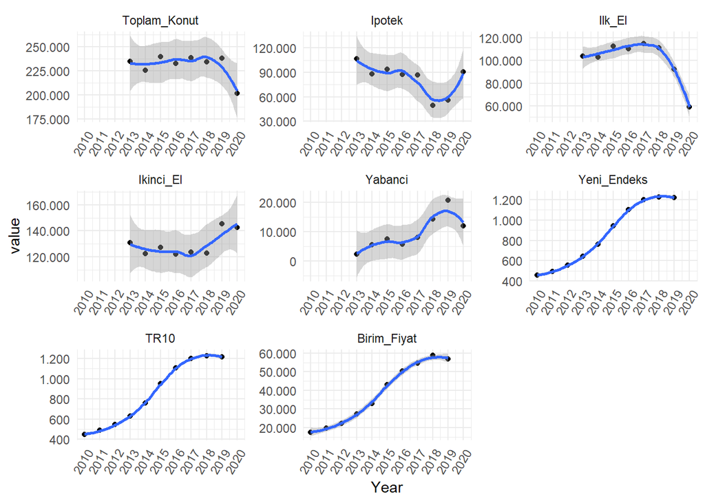

```r
yearly_data<-data%>%
                group_by(Year=year(Tarih)) %>%
                summarise_at(vars(Toplam_Konut:Birim_Fiyat), sum, na.rm = FALSE)


plot1<-melt(yearly_data, id.vars="Year")%>%
  ggplot(aes(Year,value)) +
  geom_point() +
  stat_smooth(method="loess") +
  facet_wrap(~variable,scales = "free") +theme_minimal()


plot1+
theme(legend.position="top",axis.text.x = element_text(angle=60,hjust=1,vjust=1))+
scale_y_continuous(labels=function(x) format(x, big.mark = ".", decimal.mark = ",", scientific = FALSE))+
scale_x_continuous(breaks = c(2010:2020))
```